# EWAS report

- study: Illumina methylation data
- author: Analyst
- date: 30 agosto, 2023

## Parameters

```
## $sig.threshold
## [1] 0.0001893
##
## $max.plots
## [1] 1
##
## $model
## [1] "sva"
##
## $qq.inflation.method
## [1] "median"
##
## $practical.threshold
##  cg01940273
## 1.60629e-13
##
## $winsorize.pct
## [1] 0.05
##
## $outlier.iqr.factor
## [1] NA
##
## $rlm
## [1] TRUE
##
## $most.variable
## [1] 50000
##
## $random.seed
## [1] 20161123
##
## $sample.size
## [1] 205
```

## Sample characteristics

For continuous or ordinal variables, the “mean” column provides the mean and the “var” column the standard deviation of the variable. For categorical variables, the “mean” column provides the number of samples with the given “value” and the “var” column the percentage of samples with the given “value”.

| variable | value | mean | var |
| --- | --- | --- | --- |
| variable of interest | never | 99 | 48.3 |
| variable of interest | former | 106 | 51.7 |
| Age |  | 53.94146 | 11.22613 |
| Sex | F | 144 | 70.2 |
| Sex | M | 61 | 29.8 |
| Bcell |  | 0.06650484 | 0.02367547 |
| CD4T |  | 0.1860588 | 0.05755281 |
| CD8T |  | 0.1098392 | 0.04420296 |
| Mono |  | 0.09768935 | 0.0203169 |
| Neu |  | 0.4975204 | 0.09298999 |
| NK |  | 0.09133433 | 0.03464189 |

## Covariate associations

### Covariate Age

statistics

| var1 | var2 | F | p-value | R | p-value |
| --- | --- | --- | --- | --- | --- |
| variable | Age | 2.178336 | 0.1415151 | 0.0693262 | 0.3232903 |

cases

| variable | mean | var | n | t.stat | p.value |
| --- | --- | --- | --- | --- | --- |
| never | 52.74747 | 156.76211 | 99 | -1.463778 | 0.1449471 |
| former | 55.05660 | 95.93962 | 106 | 1.463778 | 0.1449471 |

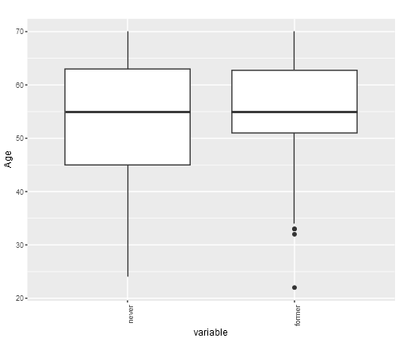

### Covariate Sex

statistics

| var1 | var2 | R | p-value |
| --- | --- | --- | --- |
| variable | Sex | 0.1806061 | 0.0095581 |

frequencies

|  | F | M |
| --- | --- | --- |
| never | 78 | 21 |
| former | 66 | 40 |

enrichment p-values

|  | F | M |
| --- | --- | --- |
| never | 0.0072320 | 0.9970825 |
| former | 0.9970825 | 0.0072320 |

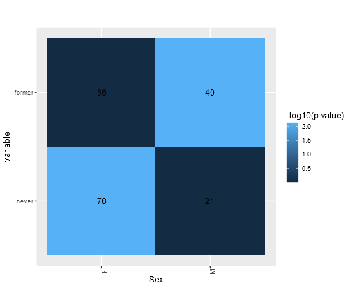

### Covariate Bcell

statistics

| var1 | var2 | F | p-value | R | p-value |
| --- | --- | --- | --- | --- | --- |
| variable | Bcell | 0.0873176 | 0.7679175 | -0.0527863 | 0.4522388 |

cases

| variable | mean | var | n | t.stat | p.value |
| --- | --- | --- | --- | --- | --- |
| never | 0.0670116 | 0.0004847 | 99 | 0.2968685 | 0.7668718 |
| former | 0.0660316 | 0.0006362 | 106 | -0.2968685 | 0.7668718 |

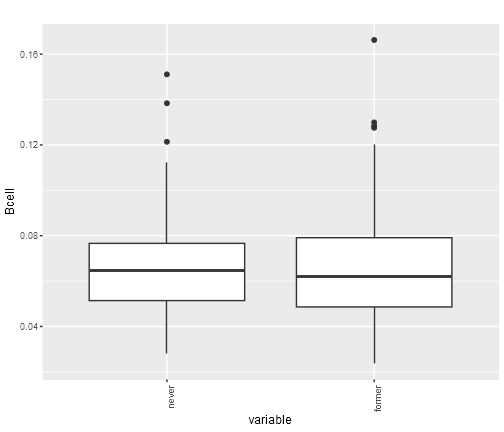

### Covariate CD4T

statistics

| var1 | var2 | F | p-value | R | p-value |
| --- | --- | --- | --- | --- | --- |
| variable | CD4T | 0.5759586 | 0.4487811 | 0.0414043 | 0.5555616 |

cases

| variable | mean | var | n | t.stat | p.value |
| --- | --- | --- | --- | --- | --- |
| never | 0.1828989 | 0.0033585 | 99 | -0.7586215 | 0.4489645 |
| former | 0.1890100 | 0.0032826 | 106 | 0.7586215 | 0.4489645 |

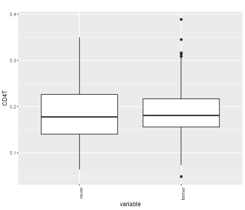

### Covariate CD8T

statistics

| var1 | var2 | F | p-value | R | p-value |
| --- | --- | --- | --- | --- | --- |
| variable | CD8T | 2.224449 | 0.1373934 | -0.0673026 | 0.3376488 |

cases

| variable | mean | var | n | t.stat | p.value |
| --- | --- | --- | --- | --- | --- |
| never | 0.1145895 | 0.0023595 | 99 | 1.480943 | 0.140288 |
| former | 0.1054026 | 0.0015528 | 106 | -1.480943 | 0.140288 |

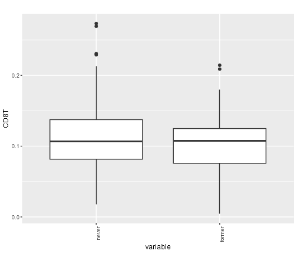

### Covariate Mono

statistics

| var1 | var2 | F | p-value | R | p-value |
| --- | --- | --- | --- | --- | --- |
| variable | Mono | 0.0015309 | 0.9688275 | 0.0161658 | 0.818046 |

cases

| variable | mean | var | n | t.stat | p.value |
| --- | --- | --- | --- | --- | --- |
| never | 0.0977469 | 0.0004783 | 99 | 0.0389298 | 0.9689864 |
| former | 0.0976356 | 0.0003555 | 106 | -0.0389298 | 0.9689864 |

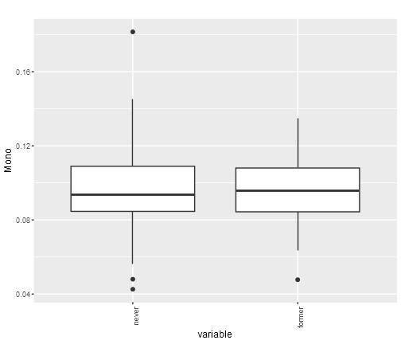

### Covariate Neu

statistics

| var1 | var2 | F | p-value | R | p-value |
| --- | --- | --- | --- | --- | --- |
| variable | Neu | 0.1140503 | 0.7359282 | 0.0333214 | 0.6352833 |

cases

| variable | mean | var | n | t.stat | p.value |
| --- | --- | --- | --- | --- | --- |
| never | 0.4952459 | 0.0088404 | 99 | -0.3375129 | 0.7360816 |
| former | 0.4996447 | 0.0085397 | 106 | 0.3375129 | 0.7360816 |

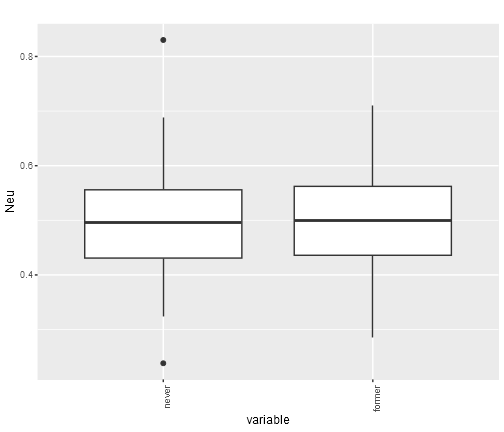

### Covariate NK

statistics

| var1 | var2 | F | p-value | R | p-value |
| --- | --- | --- | --- | --- | --- |
| variable | NK | 0.0320173 | 0.8581681 | 0.0217744 | 0.7566433 |

cases

| variable | mean | var | n | t.stat | p.value |
| --- | --- | --- | --- | --- | --- |
| never | 0.0908853 | 0.0013115 | 99 | -0.1784158 | 0.8585785 |
| former | 0.0917537 | 0.0011071 | 106 | 0.1784158 | 0.8585785 |

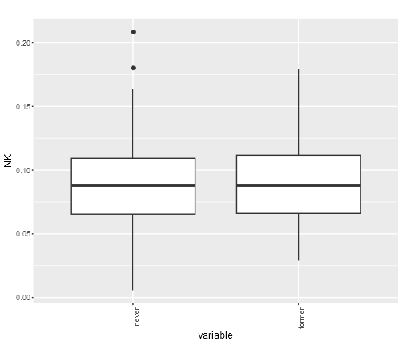

## QQ plots

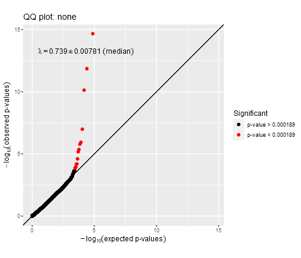

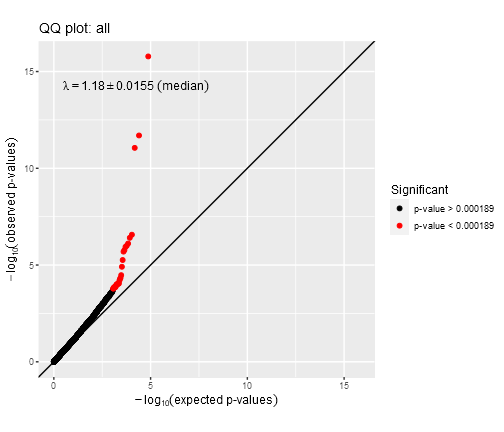

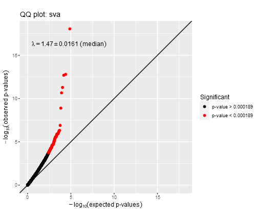

## Manhattan plots

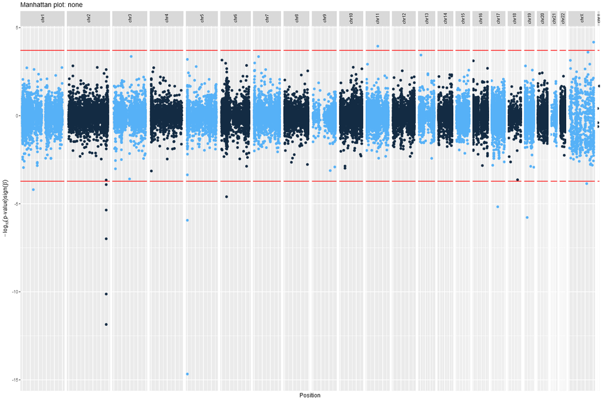

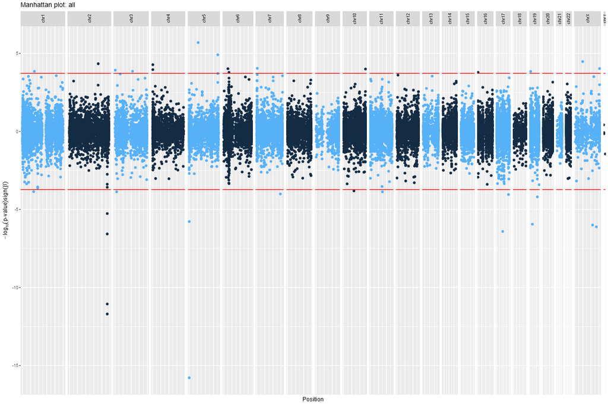

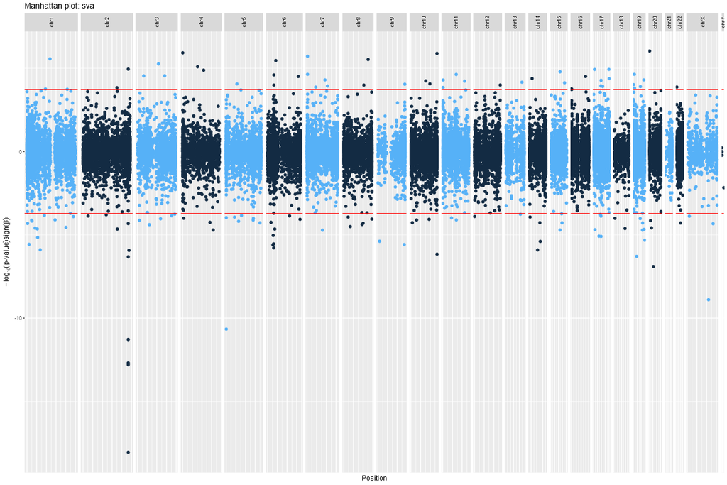

## Significant CpG sites

There were 157 CpG sites with association p-values < 1.893 × 10<sup>-4</sup>. These are listed in the file associations.csv.

The following table shows overlaps between associations under different sets of covariates:

|  | p.value.none | p.value.all | p.value.sva |
| --- | --- | --- | --- |
| p.value.none | 14 | 10 | 13 |
| p.value.all | 10 | 33 | 17 |
| p.value.sva | 13 | 17 | 140 |

|  | chromosome | position | p.value.none | p.value.all | p.value.sva | coefficient.none | coefficient.all | coefficient.sva |
| --- | --- | --- | --- | --- | --- | --- | --- | --- |
| cg05951221 | chr2 | 233284402 | 0 | 0 | 0 | -0.0564848 | -0.0540633 | -0.0517851 |
| cg05575921 | chr5 | 373378 | 0 | 0 | 0 | -0.0466583 | -0.0446954 | -0.0356144 |

Plots of these sites follow, one for each covariate set. “p[lm]” denotes the p-value obtained using a linear model and “p[beta]” the p-value obtained using beta regression.

### CpG site cg05951221

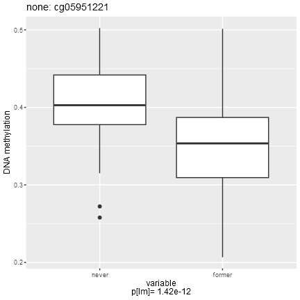

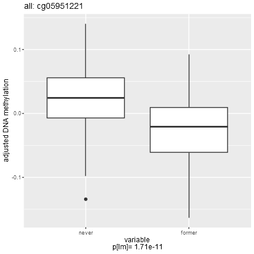

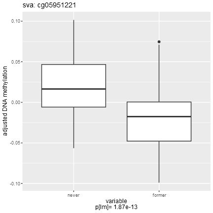

### CpG site cg05575921

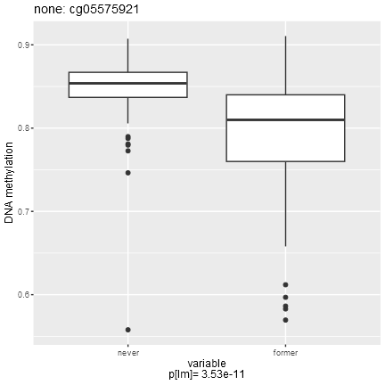

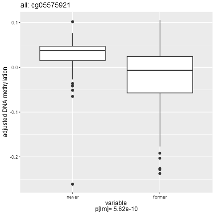

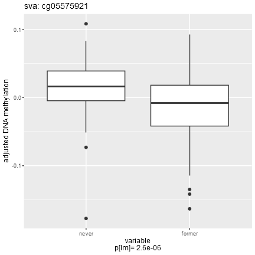

## Selected CpG sites

Number of CpG sites selected: 1.

|  | chromosome | position | p.value.none | p.value.all | p.value.sva | coefficient.none | coefficient.all | coefficient.sva |
| --- | --- | --- | --- | --- | --- | --- | --- | --- |
| cg05575921 | chr5 | 373378 | 0 | 0 | 0 | -0.0466583 | -0.0446954 | -0.0356144 |

### CpG site cg05575921

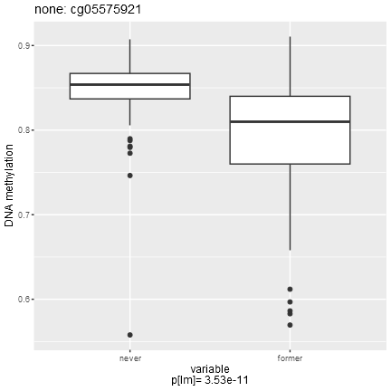

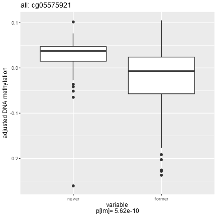

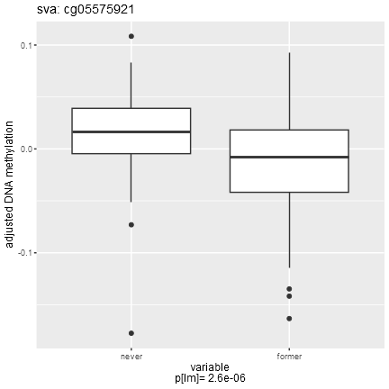